# Biodiversity in National Parks in the United States of America

Exploratory Data Analysis by Sangeetha Ramanuj and Shea O’Day

## Questions

“Biodiversity” is the foundation of life on Earth. Though the estimated 8.7 million species on Earth may seem to dismiss the importance of one species’ existence, each species is an integrated and significant part of their ecosystems. The National Geographic Society [2] defines conservation as “the care and protection of these ‘natural’ resources so that they can persist for future generations,” including “maintaining diversity of species, genes, and ecosystems, as well as functions of the environment.” As stated in the above definition, a major goal of conservation is to allow resources to persist for the future. The key is maintaining sustainable habitats for the preservation of these species.

In this paper, we explore the records of species throughout US National Parks to illustrate the biodiversity and ecosystem threats of national parks in the United States. We ask:

1. Does location and park size impact the biodiversity and number of species threatened in national parks?
2. How do different types of species make up the biodiversity of the national parks? Which national parks have the largest numbers of species with a conservation status?

To illustrate this, we look at recorded species counts in 56 of the United States national parks, and analyze the types of species that make up the parks.

## Methods

We first identify the unit of analysis of this project, **(national parks)**, which is an independent variable. The metric of biodiversity for each national park is the **total species count** in it. Other dependent variables are park location (latitude, longitude) and type of species (birds, mammals, etc.). The other metric of interest is the **count of species with a conservation status**, i.e. the nature of threat to that species. The analytic data set contains 56 unique observations each representing a national park and 33 variables. Variables document its location, size, count of total species and specific species (mammals, amphibians, etc.), count of species with a conservation status and its specifics (count endangered species, in recovery, threatened, etc.). This was obtained from two independent data sets on parks `parks.csv` and species present in each park `species.csv` provided by the National Parks Service [1]. The species data set (containing 119,248 observations) was aggregated by park and category of species, and joined with the parks data set (containing geo-spatial attributes of 56 parks in USA) to obtain all relevant variables for the analysis. We cleansed data to eliminate observations with N/A values, and conducted full joins to ensure that no parks were dropped from either of the data sets.

## Findings

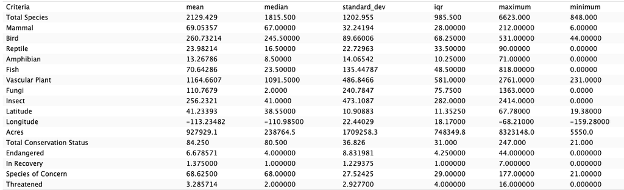

Table 1

In **Table 1**, the first row shows statistics across categories of species, followed by statistics by category, location (longitude, latitude), park area (acres) and conservation status (endangered, in-recovery, etc.). The mean total species count per park is around 2130, while the range is 5775, with a high standard deviation of 1203, indicating a vast biodiversity spread across parks. The IQR for vascular plants, insects, and fungi are also high, indicating that the central portion of the recorded data is spread out. The average number of species with a conservation status is relatively low (about 84) compared to the number of species, but goes up to 247 (maximum) in a park. The average number of endangered (<7) and threatened (<4) species are relatively low compared to the number of species per park, but go up to a high of 44 and 16, respectively.

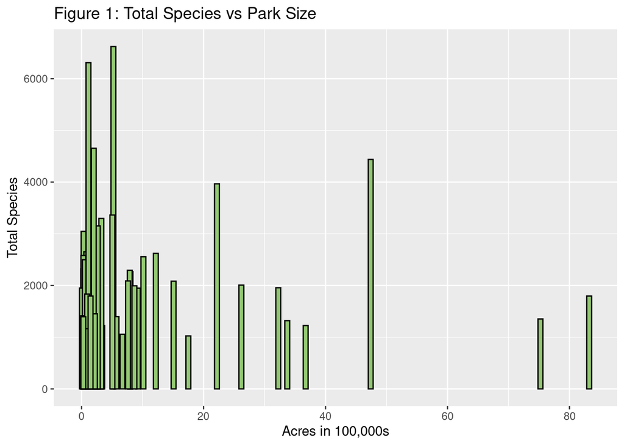

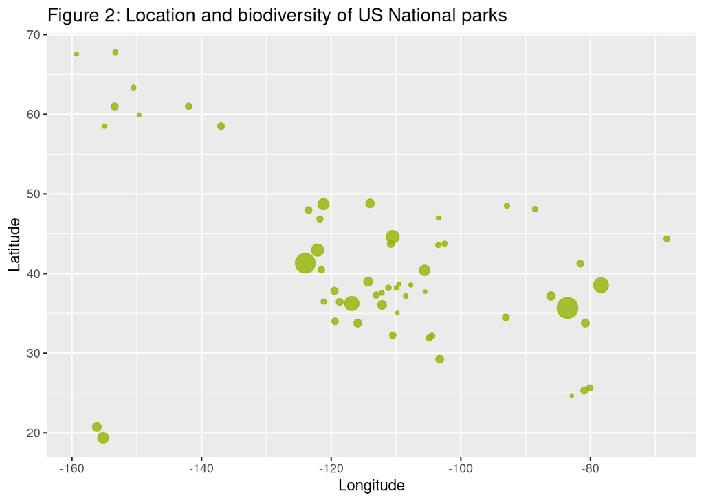

[figure not shown]

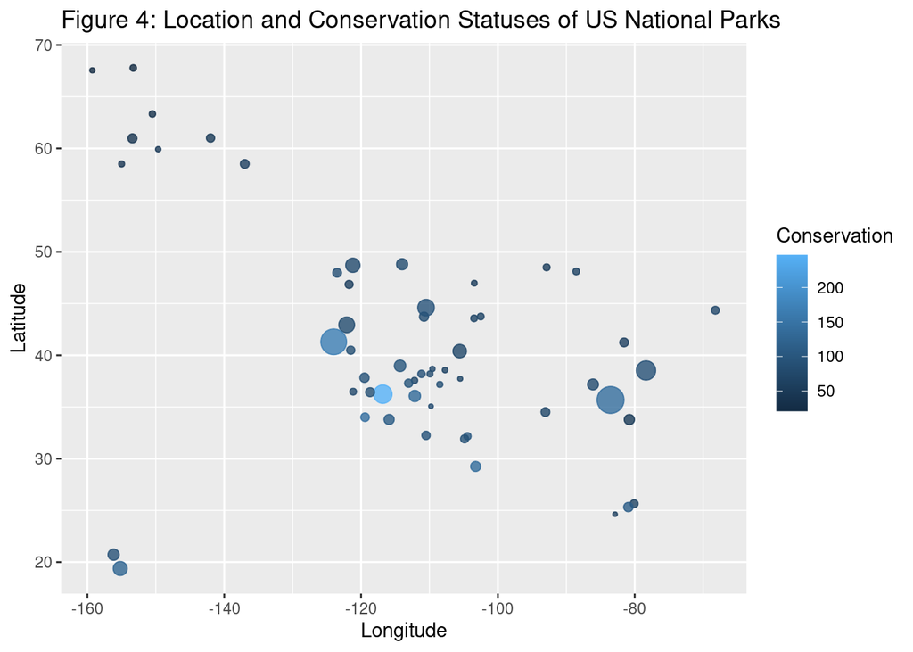

[figure not shown]

[figure not shown]

Discrepancies in data collection may have resulted in significant data gaps, yet it is beyond the scope of our project to confirm or deny validity of the data set. It is important to understand whether the total species count is actually the best metric for biodiversity. To pursue this further, we would study metrics of biodiversity with statistical analysis. We may be able to find correlations between biodiversity or threat with other park attributes. In doing so, good regression models could be built to predict whether a species type could be threatened based on the park in which it resides and its various attributes.

## References

1. National Park Service. (2017). Biodiversity in National Parks. Available from  
   https://www.kaggle.com/datasets/nationalparkservice/park-biodiversity.
2. National Geographic Society.(2023) Biodiversity. Available from https://education.nationalgeographic.org/resource/biodiversity/.